# Problem Set 2 Example Answers

Instructor data suitability check

```r
library(dplyr)
library(ggplot2)
library(here)
library(readr)

here::i_am("course_docs/instructor_examples/problem-set-2-example-answers.qmd")

flu <- read_csv(here::here("data", "real", "flu_vaccination_age_time_clean.csv"))
```

# Task 1: Dataset Orientation

One row represents one flu vaccination estimate for a specific season, month, geography, and age group. The main time variables are `season`, `season_start_year`, and `month`. Useful grouping variables include `age_group`, `geography_type`, and `geography`.

A key caution is that estimates have confidence intervals and sample sizes. Comparisons should account for uncertainty and should not treat all estimates as equally precise.

```r
flu |>
  select(season, season_start_year, month, geography, age_group, estimate, ci_lower, ci_upper, sample_size) |>
  head(10)
```

```
# A tibble: 10 × 9
   season season_start_year month geography age_group estimate ci_lower ci_upper
   <chr>              <dbl> <dbl> <chr>     <chr>        <dbl>    <dbl>    <dbl>
 1 2009-…              2009     1 Region 1  50-64 Ye…     48.5     47       50
 2 2009-…              2009     1 Region 1  >=65 Yea…     71.2     69.7     72.7
 3 2009-…              2009     1 Region 10 50-64 Ye…     42.1     40.6     43.6
 4 2009-…              2009     1 Region 10 >=65 Yea…     66.6     65.2     68
 5 2009-…              2009     1 Region 2  50-64 Ye…     42.3     40       44.6
 6 2009-…              2009     1 Region 2  >=65 Yea…     65.7     63.6     67.8
 7 2009-…              2009     1 Region 3  50-64 Ye…     48.2     46.6     49.8
 8 2009-…              2009     1 Region 3  >=65 Yea…     68       66.5     69.5
 9 2009-…              2009     1 Region 4  50-64 Ye…     40.7     39.6     41.8
10 2009-…              2009     1 Region 4  >=65 Yea…     65.8     64.8     66.8
# ℹ 1 more variable: sample_size <dbl>
```

# Task 2: Change Over Time

This plot uses national estimates for month 5 and compares three age groups over flu seasons.

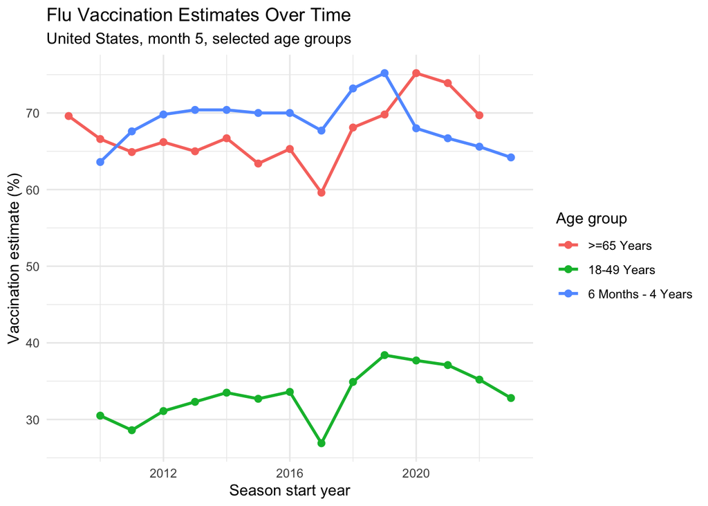

```r
us_month_5_selected <- flu |>
  filter(
    geography == "United States",
    month == 5,
    age_group %in% c("6 Months - 4 Years", "18-49 Years", ">=65 Years")
  )

p1 <- ggplot(
  us_month_5_selected,
  aes(x = season_start_year, y = estimate, color = age_group)
) +
  geom_line(linewidth = 1) +
  geom_point(size = 2) +
  labs(
    title = "Flu Vaccination Estimates Over Time",
    subtitle = "United States, month 5, selected age groups",
    x = "Season start year",
    y = "Vaccination estimate (%)",
    color = "Age group"
  ) +
  theme_minimal()

p1
```

A line plot is appropriate because the main task is change over ordered seasons. The plot also shows that age-group differences are large relative to most year-to-year changes.

# Task 3: Grouping Or Small Multiples

This plot compares the regional time pattern for adults ages 50-64 years.

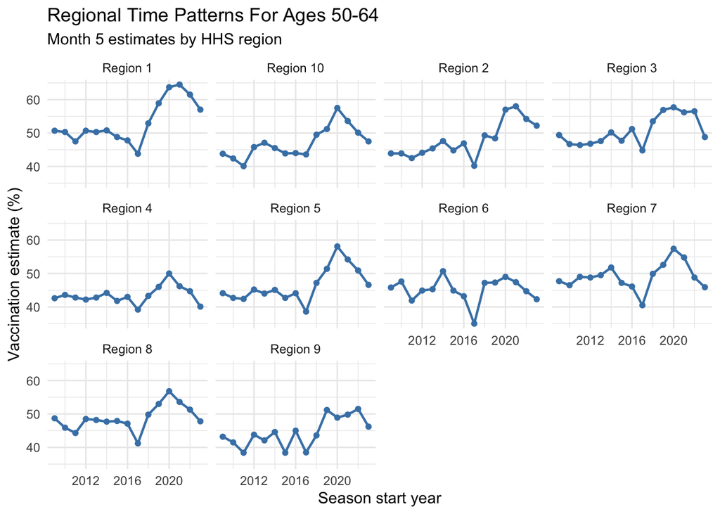

```r
regions_50_64 <- flu |>
  filter(
    geography != "United States",
    month == 5,
    age_group == "50-64 Years"
  )

p2 <- ggplot(regions_50_64, aes(x = season_start_year, y = estimate)) +
  geom_line(color = "steelblue", linewidth = 0.8) +
  geom_point(color = "steelblue", size = 1.4) +
  facet_wrap(vars(geography)) +
  labs(
    title = "Regional Time Patterns For Ages 50-64",
    subtitle = "Month 5 estimates by HHS region",
    x = "Season start year",
    y = "Vaccination estimate (%)"
  ) +
  theme_minimal()

p2
```

Faceting helps compare regional patterns without putting ten colored lines in one panel. The same axes and repeated layout make the regional differences easier to scan.

# Task 4: Uncertainty Or Data Quality

This plot uses the confidence interval columns for the national estimate among adults ages 65 and older.

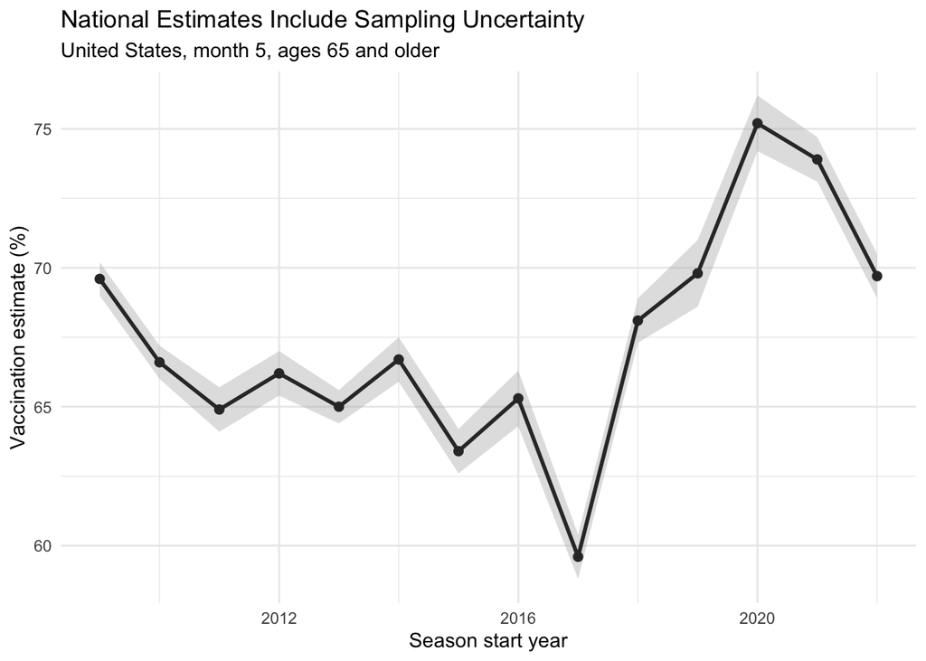

```r
us_65_uncertainty <- flu |>
  filter(
    geography == "United States",
    month == 5,
    age_group == ">=65 Years"
  )

p3 <- ggplot(us_65_uncertainty, aes(x = season_start_year, y = estimate)) +
  geom_ribbon(aes(ymin = ci_lower, ymax = ci_upper), fill = "gray70", alpha = 0.4) +
  geom_line(color = "gray20", linewidth = 1) +
  geom_point(color = "gray20", size = 2) +
  labs(
    title = "National Estimates Include Sampling Uncertainty",
    subtitle = "United States, month 5, ages 65 and older",
    x = "Season start year",
    y = "Vaccination estimate (%)"
  ) +
  theme_minimal()

p3
```

The intervals are narrow enough that broad changes over time remain visible, but they still show that each estimate has uncertainty.

# Task 5: Rough Plot To Final Plot

Here is a rough first version of the change-over-time plot.

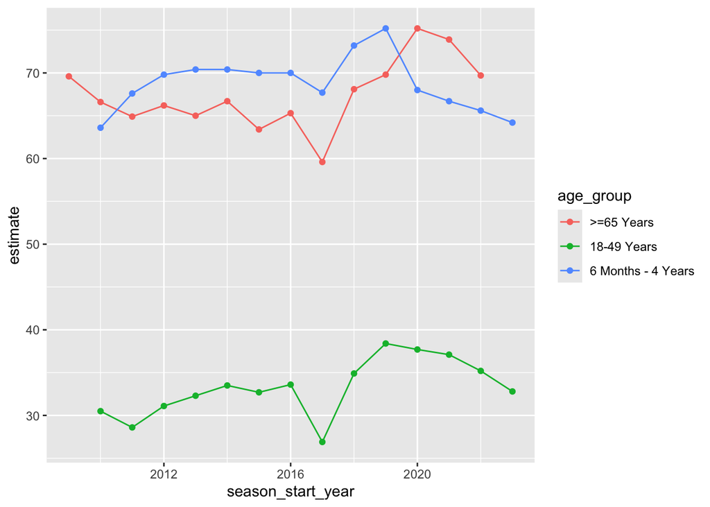

```r
rough_plot <- ggplot(us_month_5_selected, aes(x = season_start_year, y = estimate, color = age_group)) +
  geom_line() +
  geom_point()

rough_plot
```

Here is the revised version.

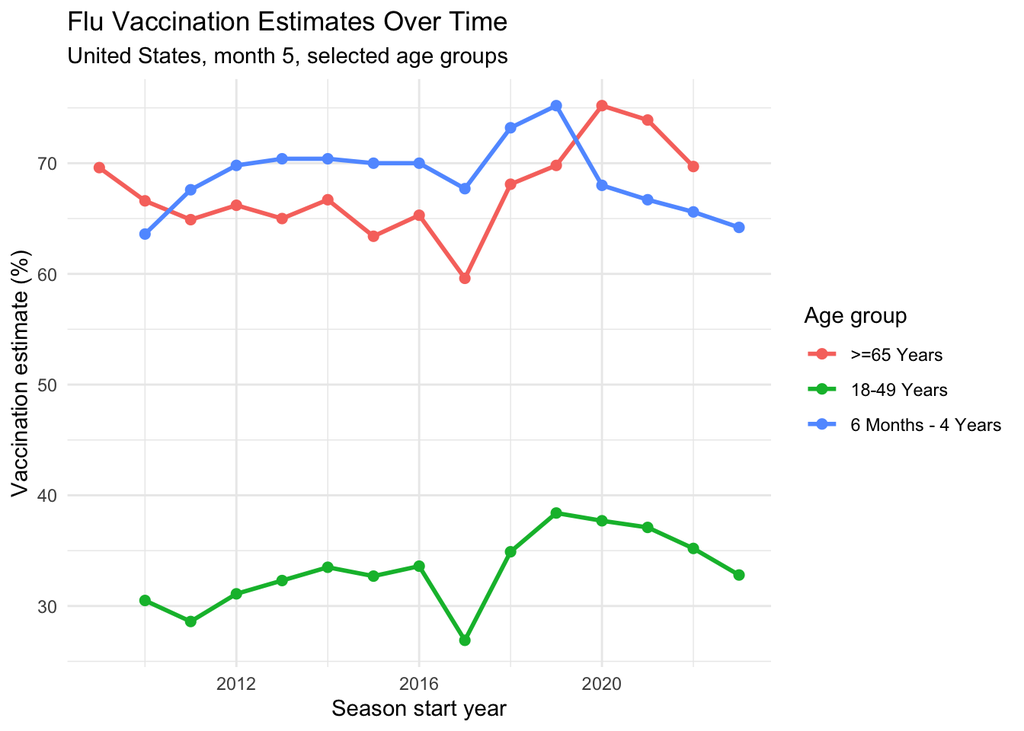

```r
p1
```

The revised version adds a title, subtitle, axis labels, legend title, stronger line weight, and a cleaner theme. Those changes make the time variable, geography, month, and compared age groups clearer.

# Data Suitability Notes

- `flu_vaccination_age_time_clean.csv` supports all required tasks.
- `season_start_year` works well for change over time.
- `age_group` and `geography` work well for grouping and faceting.
- `ci_lower`, `ci_upper`, and `sample_size` support uncertainty and data-quality checks.
- The dataset has enough seasons and groups to make students choose rather than plot everything at once.